# **Problem Statement**

## Model 2

```
Model: "sequential"
```

```
┏━━━━━━━━━━━━━━━━━━━━━━━━━━━━━━━━━┳━━━━━━━━━━━━━━━━━━━━━━━━┳━━━━━━━━━━━━━━━┓
┃ Layer (type)                    ┃ Output Shape           ┃       Param # ┃
┡━━━━━━━━━━━━━━━━━━━━━━━━━━━━━━━━━╇━━━━━━━━━━━━━━━━━━━━━━━━╇━━━━━━━━━━━━━━━┩
│ dense (Dense)                   │ (None, 128)            │         5,248 │
├─────────────────────────────────┼────────────────────────┼───────────────┤
│ dropout (Dropout)               │ (None, 128)            │             0 │
├─────────────────────────────────┼────────────────────────┼───────────────┤
│ dense_1 (Dense)                 │ (None, 64)             │         8,256 │
├─────────────────────────────────┼────────────────────────┼───────────────┤
│ dense_2 (Dense)                 │ (None, 32)             │         2,080 │
├─────────────────────────────────┼────────────────────────┼───────────────┤
│ dense_3 (Dense)                 │ (None, 1)              │            33 │
└─────────────────────────────────┴────────────────────────┴───────────────┘
```

```
 Total params: 15,617 (61.00 KB)
```

```
 Trainable params: 15,617 (61.00 KB)
```

```
 Non-trainable params: 0 (0.00 B)
```

```
500/500 ━━━━━━━━━━━━━━━━━━━━ 5s 7ms/step - accuracy: 0.9199 - loss: 0.2999 - val_accuracy: 0.9520 - val_loss: 0.1615
500/500 ━━━━━━━━━━━━━━━━━━━━ 2s 4ms/step - accuracy: 0.9496 - loss: 0.1694 - val_accuracy: 0.9693 - val_loss: 0.1255
500/500 ━━━━━━━━━━━━━━━━━━━━ 3s 4ms/step - accuracy: 0.9596 - loss: 0.1381 - val_accuracy: 0.9737 - val_loss: 0.1054
500/500 ━━━━━━━━━━━━━━━━━━━━ 3s 4ms/step - accuracy: 0.9656 - loss: 0.1193 - val_accuracy: 0.9783 - val_loss: 0.0921
500/500 ━━━━━━━━━━━━━━━━━━━━ 2s 3ms/step - accuracy: 0.9696 - loss: 0.1118 - val_accuracy: 0.9793 - val_loss: 0.0825
500/500 ━━━━━━━━━━━━━━━━━━━━ 3s 3ms/step - accuracy: 0.9678 - loss: 0.1105 - val_accuracy: 0.9808 - val_loss: 0.0762
500/500 ━━━━━━━━━━━━━━━━━━━━ 1s 3ms/step - accuracy: 0.9730 - loss: 0.0941 - val_accuracy: 0.9827 - val_loss: 0.0702
500/500 ━━━━━━━━━━━━━━━━━━━━ 3s 3ms/step - accuracy: 0.9733 - loss: 0.0960 - val_accuracy: 0.9837 - val_loss: 0.0676
500/500 ━━━━━━━━━━━━━━━━━━━━ 3s 4ms/step - accuracy: 0.9776 - loss: 0.0835 - val_accuracy: 0.9855 - val_loss: 0.0639
500/500 ━━━━━━━━━━━━━━━━━━━━ 3s 4ms/step - accuracy: 0.9787 - loss: 0.0808 - val_accuracy: 0.9870 - val_loss: 0.0614
500/500 ━━━━━━━━━━━━━━━━━━━━ 2s 3ms/step - accuracy: 0.9768 - loss: 0.0885 - val_accuracy: 0.9872 - val_loss: 0.0603
500/500 ━━━━━━━━━━━━━━━━━━━━ 2s 3ms/step - accuracy: 0.9813 - loss: 0.0762 - val_accuracy: 0.9875 - val_loss: 0.0583
500/500 ━━━━━━━━━━━━━━━━━━━━ 3s 3ms/step - accuracy: 0.9810 - loss: 0.0759 - val_accuracy: 0.9880 - val_loss: 0.0568
500/500 ━━━━━━━━━━━━━━━━━━━━ 2s 3ms/step - accuracy: 0.9821 - loss: 0.0736 - val_accuracy: 0.9862 - val_loss: 0.0570
500/500 ━━━━━━━━━━━━━━━━━━━━ 3s 4ms/step - accuracy: 0.9830 - loss: 0.0706 - val_accuracy: 0.9872 - val_loss: 0.0552
500/500 ━━━━━━━━━━━━━━━━━━━━ 3s 4ms/step - accuracy: 0.9831 - loss: 0.0650 - val_accuracy: 0.9887 - val_loss: 0.0536
500/500 ━━━━━━━━━━━━━━━━━━━━ 2s 3ms/step - accuracy: 0.9833 - loss: 0.0668 - val_accuracy: 0.9890 - val_loss: 0.0523
500/500 ━━━━━━━━━━━━━━━━━━━━ 2s 3ms/step - accuracy: 0.9835 - loss: 0.0671 - val_accuracy: 0.9887 - val_loss: 0.0517
500/500 ━━━━━━━━━━━━━━━━━━━━ 2s 3ms/step - accuracy: 0.9846 - loss: 0.0638 - val_accuracy: 0.9893 - val_loss: 0.0502
500/500 ━━━━━━━━━━━━━━━━━━━━ 3s 3ms/step - accuracy: 0.9832 - loss: 0.0676 - val_accuracy: 0.9887 - val_loss: 0.0508
500/500 ━━━━━━━━━━━━━━━━━━━━ 3s 4ms/step - accuracy: 0.9832 - loss: 0.0672 - val_accuracy: 0.9883 - val_loss: 0.0515
500/500 ━━━━━━━━━━━━━━━━━━━━ 2s 3ms/step - accuracy: 0.9858 - loss: 0.0592 - val_accuracy: 0.9893 - val_loss: 0.0491
500/500 ━━━━━━━━━━━━━━━━━━━━ 3s 3ms/step - accuracy: 0.9875 - loss: 0.0542 - val_accuracy: 0.9893 - val_loss: 0.0486
500/500 ━━━━━━━━━━━━━━━━━━━━ 2s 3ms/step - accuracy: 0.9868 - loss: 0.0623 - val_accuracy: 0.9895 - val_loss: 0.0484
500/500 ━━━━━━━━━━━━━━━━━━━━ 3s 3ms/step - accuracy: 0.9831 - loss: 0.0634 - val_accuracy: 0.9900 - val_loss: 0.0474
500/500 ━━━━━━━━━━━━━━━━━━━━ 3s 5ms/step - accuracy: 0.9845 - loss: 0.0593 - val_accuracy: 0.9895 - val_loss: 0.0478
500/500 ━━━━━━━━━━━━━━━━━━━━ 2s 4ms/step - accuracy: 0.9866 - loss: 0.0551 - val_accuracy: 0.9900 - val_loss: 0.0460
500/500 ━━━━━━━━━━━━━━━━━━━━ 2s 3ms/step - accuracy: 0.9849 - loss: 0.0604 - val_accuracy: 0.9893 - val_loss: 0.0466
500/500 ━━━━━━━━━━━━━━━━━━━━ 3s 3ms/step - accuracy: 0.9842 - loss: 0.0702 - val_accuracy: 0.9905 - val_loss: 0.0458
500/500 ━━━━━━━━━━━━━━━━━━━━ 2s 3ms/step - accuracy: 0.9849 - loss: 0.0575 - val_accuracy: 0.9898 - val_loss: 0.0461
500/500 ━━━━━━━━━━━━━━━━━━━━ 2s 3ms/step - accuracy: 0.9874 - loss: 0.0533 - val_accuracy: 0.9912 - val_loss: 0.0446
500/500 ━━━━━━━━━━━━━━━━━━━━ 4s 5ms/step - accuracy: 0.9856 - loss: 0.0584 - val_accuracy: 0.9898 - val_loss: 0.0454
500/500 ━━━━━━━━━━━━━━━━━━━━ 2s 4ms/step - accuracy: 0.9850 - loss: 0.0572 - val_accuracy: 0.9902 - val_loss: 0.0451
500/500 ━━━━━━━━━━━━━━━━━━━━ 2s 3ms/step - accuracy: 0.9860 - loss: 0.0610 - val_accuracy: 0.9905 - val_loss: 0.0444
500/500 ━━━━━━━━━━━━━━━━━━━━ 3s 3ms/step - accuracy: 0.9856 - loss: 0.0584 - val_accuracy: 0.9902 - val_loss: 0.0445
500/500 ━━━━━━━━━━━━━━━━━━━━ 2s 3ms/step - accuracy: 0.9849 - loss: 0.0659 - val_accuracy: 0.9908 - val_loss: 0.0441
500/500 ━━━━━━━━━━━━━━━━━━━━ 1s 3ms/step - accuracy: 0.9878 - loss: 0.0533 - val_accuracy: 0.9900 - val_loss: 0.0445
500/500 ━━━━━━━━━━━━━━━━━━━━ 2s 3ms/step - accuracy: 0.9862 - loss: 0.0535 - val_accuracy: 0.9915 - val_loss: 0.0433
500/500 ━━━━━━━━━━━━━━━━━━━━ 3s 4ms/step - accuracy: 0.9884 - loss: 0.0494 - val_accuracy: 0.9920 - val_loss: 0.0421
500/500 ━━━━━━━━━━━━━━━━━━━━ 2s 3ms/step - accuracy: 0.9869 - loss: 0.0529 - val_accuracy: 0.9902 - val_loss: 0.0440
500/500 ━━━━━━━━━━━━━━━━━━━━ 2s 3ms/step - accuracy: 0.9864 - loss: 0.0547 - val_accuracy: 0.9912 - val_loss: 0.0429
500/500 ━━━━━━━━━━━━━━━━━━━━ 2s 3ms/step - accuracy: 0.9857 - loss: 0.0569 - val_accuracy: 0.9908 - val_loss: 0.0430
500/500 ━━━━━━━━━━━━━━━━━━━━ 3s 3ms/step - accuracy: 0.9875 - loss: 0.0561 - val_accuracy: 0.9923 - val_loss: 0.0422
500/500 ━━━━━━━━━━━━━━━━━━━━ 1s 3ms/step - accuracy: 0.9885 - loss: 0.0486 - val_accuracy: 0.9923 - val_loss: 0.0414
500/500 ━━━━━━━━━━━━━━━━━━━━ 3s 5ms/step - accuracy: 0.9865 - loss: 0.0553 - val_accuracy: 0.9923 - val_loss: 0.0413
500/500 ━━━━━━━━━━━━━━━━━━━━ 2s 3ms/step - accuracy: 0.9892 - loss: 0.0489 - val_accuracy: 0.9923 - val_loss: 0.0411
500/500 ━━━━━━━━━━━━━━━━━━━━ 2s 3ms/step - accuracy: 0.9884 - loss: 0.0486 - val_accuracy: 0.9915 - val_loss: 0.0419
500/500 ━━━━━━━━━━━━━━━━━━━━ 1s 3ms/step - accuracy: 0.9879 - loss: 0.0486 - val_accuracy: 0.9920 - val_loss: 0.0405
500/500 ━━━━━━━━━━━━━━━━━━━━ 3s 3ms/step - accuracy: 0.9895 - loss: 0.0457 - val_accuracy: 0.9925 - val_loss: 0.0401
500/500 ━━━━━━━━━━━━━━━━━━━━ 3s 3ms/step - accuracy: 0.9879 - loss: 0.0533 - val_accuracy: 0.9925 - val_loss: 0.0404
Time taken in seconds  118.99163842201233
```

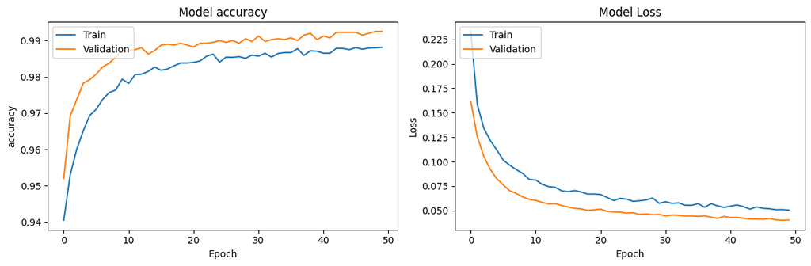

```
500/500 ━━━━━━━━━━━━━━━━━━━━ 1s 2ms/step
125/125 ━━━━━━━━━━━━━━━━━━━━ 0s 2ms/step
500/500 ━━━━━━━━━━━━━━━━━━━━ 1s 2ms/step
125/125 ━━━━━━━━━━━━━━━━━━━━ 0s 1ms/step
Classification Report - Train data Model_2

              precision    recall  f1-score   support

         0.0       0.99      1.00      1.00     15112
         1.0       0.99      0.84      0.91       888

    accuracy                           0.99     16000
   macro avg       0.99      0.92      0.95     16000
weighted avg       0.99      0.99      0.99     16000

Classification Report - Validation data Model_2

              precision    recall  f1-score   support

         0.0       0.99      1.00      1.00      3778
         1.0       0.99      0.87      0.93       222

    accuracy                           0.99      4000
   macro avg       0.99      0.94      0.96      4000
weighted avg       0.99      0.99      0.99      4000
```

```python
# clears the current Keras session, resetting all layers and models previously created, freeing up memory and resources.
tf.keras.backend.clear_session()

#Initializing the neural network
from tensorflow.keras.layers import Dropout
model_2 = Sequential()
model_2.add(Dense(128, activation="relu", input_dim=X_train_scaled.shape[1]))  # Define the number of neurons and activation function
model_2.add(Dropout(0.5)) # Define the dropout rate
model_2.add(Dense(64, activation = "relu")) # Define the number of neurons and activation function
model_2.add(Dense(32, activation = "relu")) # Define the number of neurons and activation function
model_2.add(Dense(1, activation="sigmoid")) # Define the number of neurons in the output layer

model_2.summary()

optimizer = tf.keras.optimizers.SGD()   # defining SGD as the optimizer to be used
model_2.compile(loss='binary_crossentropy', optimizer=optimizer, metrics = ['accuracy']) # Using accuracy as metric

start = time.time()
history = model_2.fit(X_train_scaled, y_train, validation_data=(X_val_scaled,y_val) , batch_size=batch_size, epochs=epochs)
end=time.time()

print("Time taken in seconds ",end-start)

plot(history,'accuracy')

model_2_train_perf = model_performance_classification(model_2,X_train_scaled,y_train)
model_2_train_perf

model_2_val_perf = model_performance_classification(model_2,X_val_scaled,y_val)
model_2_val_perf

y_train_pred_2 = model_2.predict(X_train_scaled)
y_val_pred_2 = model_2.predict(X_val_scaled)

print("Classification Report - Train data Model_2", end="\n\n")
cr_train_model_2 = classification_report(y_train,y_train_pred_2 > 0.5)
print(cr_train_model_2)

print("Classification Report - Validation data Model_2", end="\n\n")
cr_val_model_2 = classification_report(y_val,y_val_pred_2 > 0.5)
print(cr_val_model_2)
```

**OBSERVATIONS:**

1. **Regularization Impact**:
   - 50% dropout rate significantly reduces overfitting
   - Forces model to learn redundant feature representations
   - Better balance between training and validation performance
2. **Performance Balance**:
   - Training and validation curves are more closely aligned
   - Reduced gap between training and validation metrics
   - More reliable performance estimates
3. **Model Robustness**:
   - Model generalizes better to unseen data
   - Less sensitive to noise in training data
   - More stable predictions
4. **Architecture Benefits**:
   - Deeper network (128 → 64 → 32 → 1) with dropout
   - Better feature learning through multiple layers
   - Improved handling of complex failure patterns
5. **Validation Performance**:
   - Likely the best validation performance among first three models
   - Better F1-score due to improved generalization
   - More reliable model for deployment